# Predicting Self Reported BMI

Catherine Al Aswad, Ali Alhakeem, Uyen Dao, Long Kim Long

Last updated: 10/03/2020

# I. Introduction

The body mass index is a measure that doctors consider when checking for health risks for their patients. The goal of this study is to create a model to predict the Self reported Body Mass Index of Canadians between the ages of 15 and 74. The study considers dwelling and household, general health, sleep, alcohol use, income, and labour force factors in the process of creating the model.

The data used in this study is from the NESSTAR data portal and collected using the 2017-2018 Canadian Community Health Survey (CCHS)[^1]. We considered 9 variables and used the 5/9 most adequate variables to predict self reported BMI[^2]. The 8 categorical variables and their corresponding levels that we considered are:

1. Sex: Female, Male[^3]
2. Marital Status: Married, Common-law, Widowed/Divorced/Separated, Single[^4]
3. Household Size: 1, 2, 3, 4, 5 or more[^5]
4. Age: [12,14], [15,17], [18,19], [20,24], [25,29], [30,34], [35,39], [40,44], [45,49], [50,54], [55,59], [60,64], [65,69], [70,74], [75,79], 80 and older[^6]
5. Perceived Life Stress: Not at all stressful, Not very stressful, A bit stressful, Quite a bit stressful, Extremely stressful[^7]
6. Number of hours per night usually spent sleeping: Less than 3, [3,4), [4,5), [5,6), [6,7), [7,8), [8,9), [9,10), [10,11), [11,12), 12 or more[^8]
7. Drank alcohol - frequency in the last 12 months: less than once a month, once a month, 2or 3 times a month, once per week, 2 or 3 times a week, 4 or 6 times a week, Everyday[^9]
8. Total household income (from all sources): [0;20,000), [20,000;39,999], [40,000;59,999], [60,000;79,999], 80,000 or more[^10]

The 9th variable that we considered is the continuous variable for the total usual hours worked per week (unit is hours)[^11].

The survey was initially given to approximately 113,290 people[^12]. However, there are missing values for the considered variables. Canadian candidates with a missing value in any of the 10 variables previously mentioned were excluded from the study; data for 24,683 candidates remained. None of the remaining candidates are between 12 and 14 nor 75 and above years old. A decision was made to exclude the [12,14] and [75 or more] age brackets from the sample instead of treating them as empty categories; the focus of the report is narrowed down to predict the self reported BMI of individuals between 15 and 74 years old.

After applying a Model Selection Algorithm using the Exhaustive Search method, it was found that the 5 distinct variables that are best to predict self reported BMI are Sex, Marital Status, Age, Drank alcohol - frequency in the last 12 months, and Total usual hours worked per week. The VIF values were calculated for the chosen variables, to check for multicollinearity. It was found that there is little to no multicollinearity, so the study will proceed with the chosen variables.

Note that the categories for the Age variable were slightly modified in this study to make the age categories of equal interval size; the categories [15,17] and [18,19] were merged to form the interval [15, 19], and the other categories remain the same.

Table 1.Sample of 5 randomly chosen rows of the data set used in this study.

| BMI_SR | Sex | Marital_Status | Age | Alcohol_Freq | Total_hours_worked_per_week |
| --- | --- | --- | --- | --- | --- |
| 29.89 | Male | Married | [35,39] | 2/month or 3/month | 40 |
| 20.21 | Female | Single | [40,44] | 2/week or 3/week | 50 |
| 22.98 | Female | Single | [45,49] | Everyday | 35 |
| 25.65 | Male | Single | [60,64] | 2/month or 3/month | 40 |
| 25.62 | Male | Married | [65,69] | Everyday | 6 |

# II. Exploratory data analysis

Table 2: Summary for Self Reported BMI (kg/$m^2$)

| n | min | median | mean | max | sd |
| --- | --- | --- | --- | --- | --- |
| 24683 | 14.79 | 25.62 | 26.34367 | 53.92 | 5.004183 |

Our total sample size was 24683 (Table 2). The mean BMI is observed to be slightly greater than the median, indicating that our BMI distribution is right-skewed, or that there are more overweight people than do underweight. Most people fall into the range of low 20s to low 30s, which is normal to borderline obese, according to the official website of CDC (Center for Disease Control and Prevention)[^13].

We notice a very clear right-skewed distribution arising from our histogram highlighting the distribution of self-reported BMI when it comes to its frequency across our observations in figure 1, with the observations mostly centering around 25 self-reported BMI. This leads us to believe that the normality of our distribution is violated.

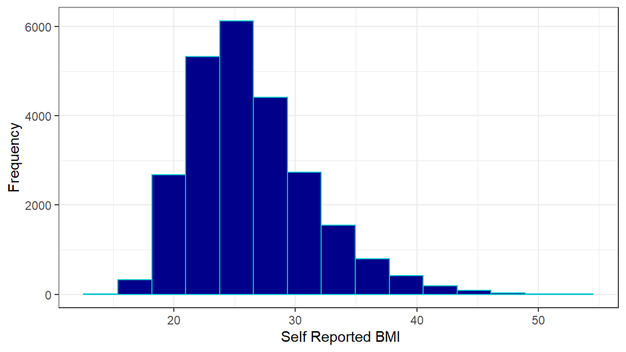

Figure 1. Distribution of Sel ReportedBMI

There is a positive relationship between the total usual hours worked per week and self reported BMI in figure 2. As the total usuals hours worked per week increases, the Self Reported BMI tends to increase. There are more people who work [0, 50] hours per week than those who work for (50,100] hours. However, there appear to be no points with great leverage nor with BMI values that are significantly larger than the main group of people.

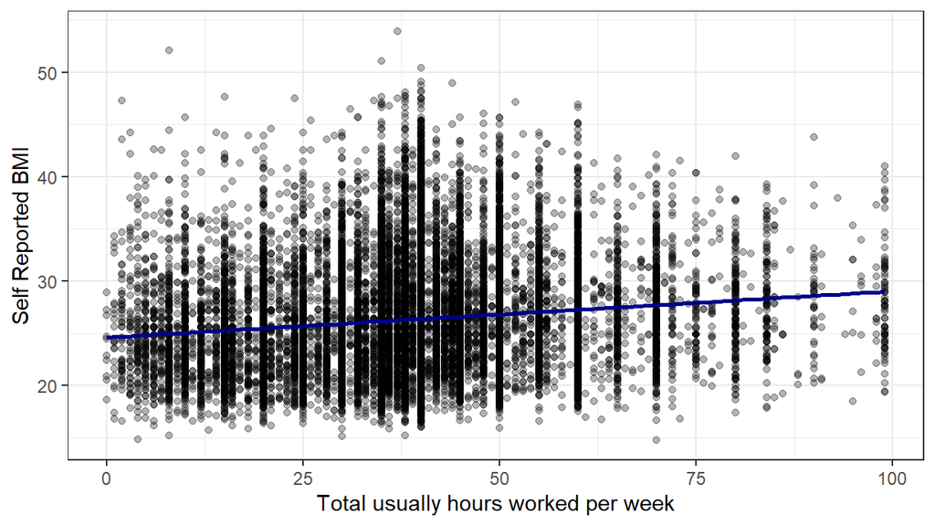

Figure 2. Relationship between the Total usually hours that a Canadoan works per week and their slef reported BMI

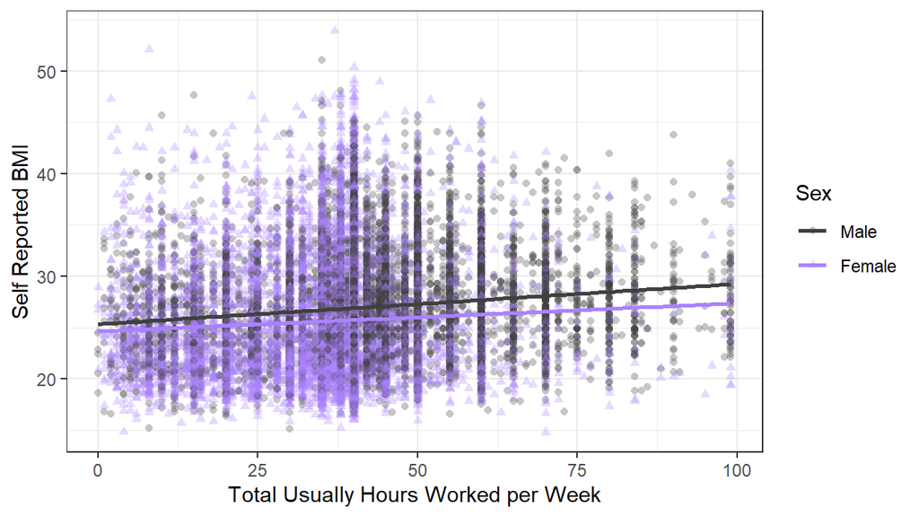

Figure 3. Relationship between Total usually hours worked per week and Self Reported BMI, grouped by Sex

We see a trend in the Boxplot distribution for age categories against self-reported BMI in figure 4. We notice a mildly upward trend as the ages get older, seeming to stabilize at 26 self-reported BMI around the 50 to 54 category and older. The interquartile ranges for self-reported BMI seem to be consistent across our age categories, with a mostly consistent right-skew as well. We notice a lot of outliers for each age category, while the 55 to 59 category has a uniquely high set of self-reported BMI of 50 and higher which should be examined.

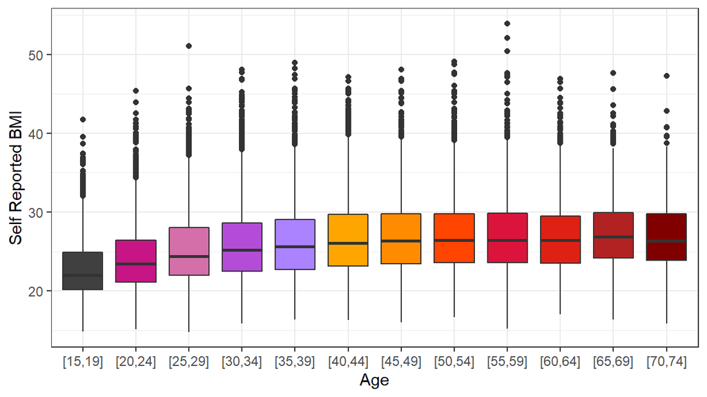

Figure 4. Boxplot of relationship between Self Reported BMI and Age

The positive relationship between self-reported BMI and total usual hours worked per week in figure 5 by marital status is not really clear. The single and common law groups show a clearer positive trend when the total usual hours worked per week increase.

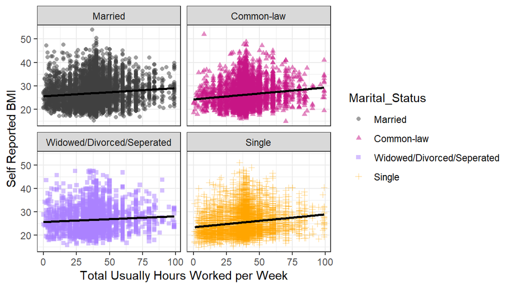

Figure 5. Relationship between total hours worked per week and Self Reported BMI, grouped by Marital Status

There is a positive relationship between the total usual hours worked per week and self reported BMI for each of the alcohol drinking frequencies for the participants (Figure 6). The rate at which BMI tends to increase, for each additional hour worked in the week, decreases as the drinking frequency of a person increases.

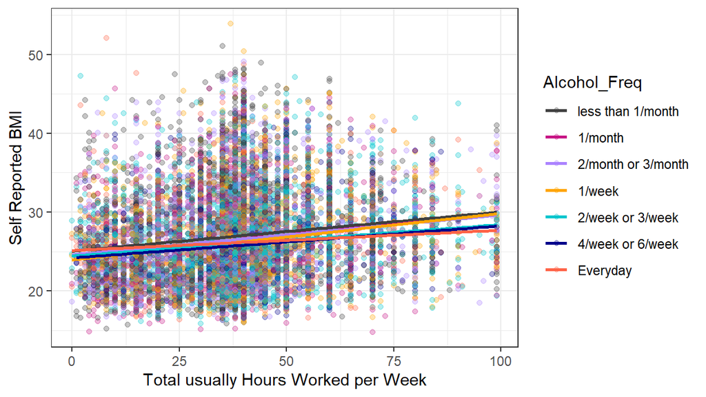

Figure 6. Relationship between Total hours worked per week and Self Reported BMI, grouped by the alcohol frequency at which the participoants drank in the past 12 months

# III. Multiple linear regression

## i. Methods

Our group initially proposed to use a linear model on the given data, then performed a residual analysis, as an in-sample validation method, to detect any systematic departure from the assumptions upon which the model is built: normality, independence, and homoscedasticity of the residuals. In Figure 7., we are presented with a normal QQ-plot of the residuals, which plots the theoretical quantiles against their observed sample counterparts. We notice that the graph curves upwards, suggesting some level of right-skewness in the distribution. This is confirmed in Figure 8, showing the histogram of the error terms.

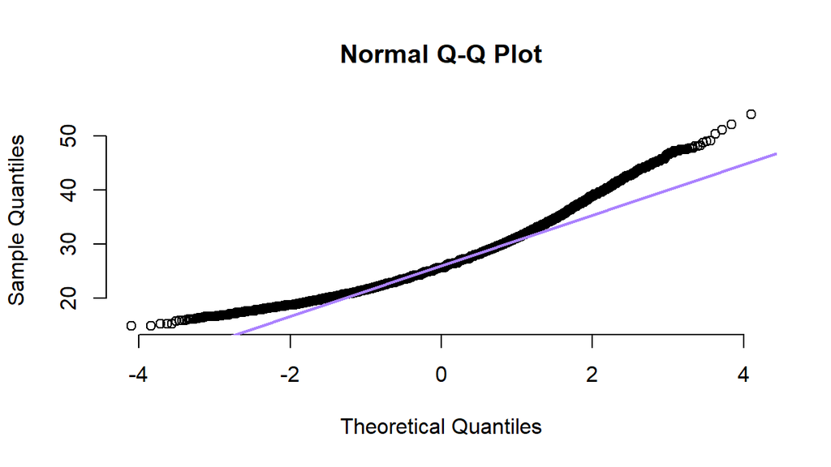

Figure 7. Normal Q-Qplot for the model under discussion

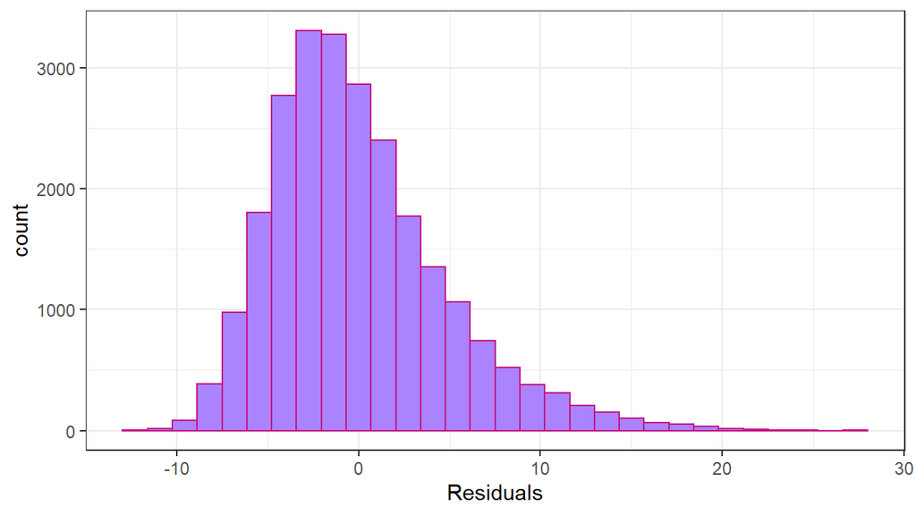

Figure 8. Residuals distribution for the statistical model

Not only that, Figure 9 presents a fanning-out pattern of the residuals, implying that the variance is non-constant, or heteroscedasticity.

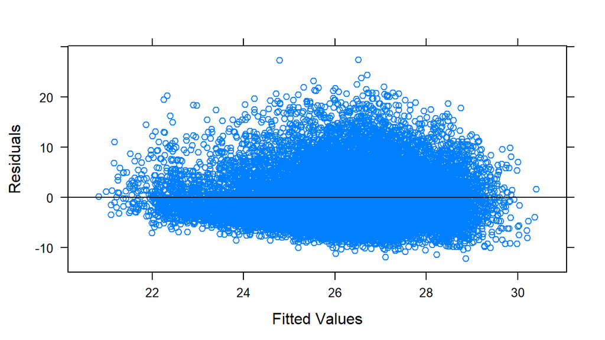

Figure 9. Residuals graph for the fitted values.

Due to the violation of the normality assumption mentioned in the previous, we recognize that a transformation is much needed. Using the method of log-likelihood (Figure 10), our dependent variable (BMI) will be transformed by the below factor: (-0.828).

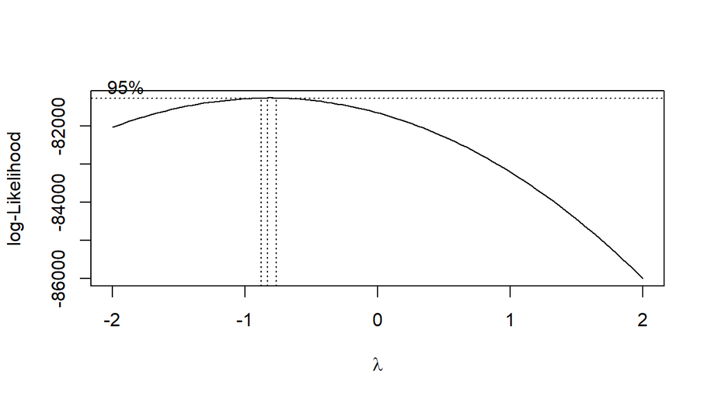

Figure 10. Graph resulting from a Box Cox Test

Lambda, the value for which Y will be raised to, to transform the model (i.e $Y^{lambda}$):

| Lambda |
| --- |
| -0.8282828 |

Comparing the residual graphs (Figure 11, 12, 13) of the transformed data with what we started with, we observe that the distribution of error terms is fixed to resemble a bell shape, the normal Q-Q plot shows an almost straight line, and the residual scatterplot is cloud-shaped. It is evident that the transformation has allowed our assumptions about the model to be reasonably met in order to proceed with our analysis.

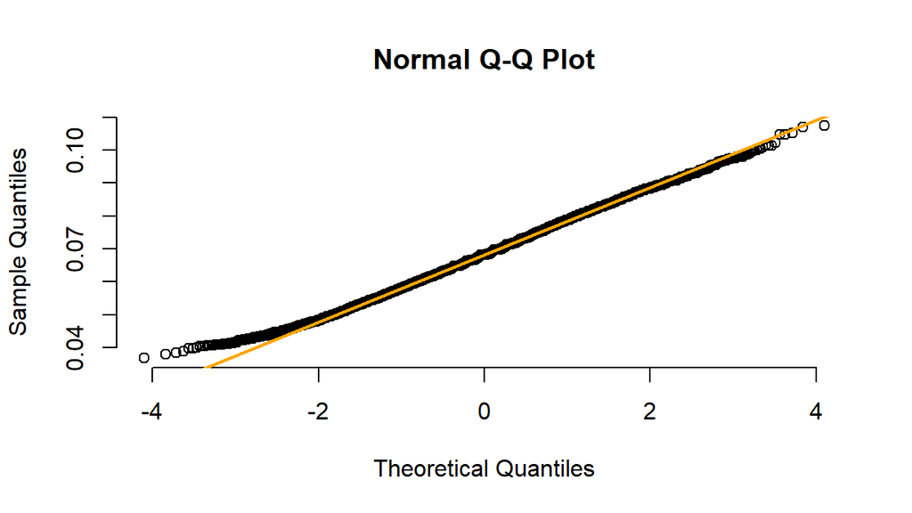

Figure 11. Normal QQplot for transformed model

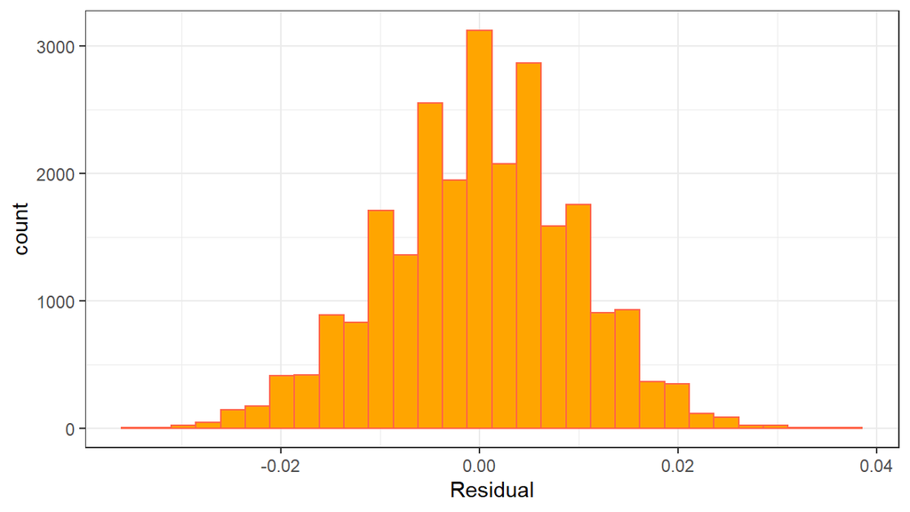

Figure 12. Residuals distribution for the transformed statistical model

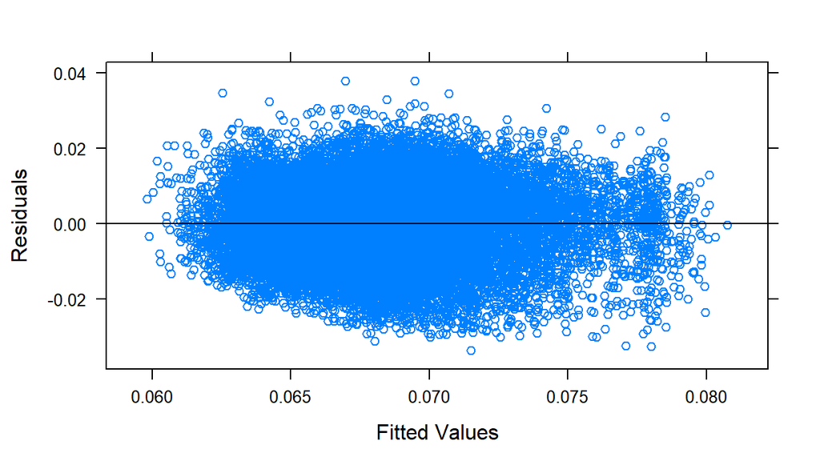

Figure 13. Residuals against the fitted values of the transformed model.

To ensure that multicollinearity is not a problem in the transformed model, the VIF values were calculated for the variables in the transformed model, to check for multicollinearity. It was found that there is little to no multicollinearity, so the study will proceed with the chosen model transformation.

## ii. Model Results

Table 3. Model Summary Table.

```
##
## Call:
## lm(formula = BMI_SR_Transf ~ Sex + Total_hours_worked_per_week +
##     Marital_Status + Alcohol_Freq + Age, data = BMI_Cleaned)
##
## Residuals:
##       Min        1Q    Median        3Q       Max
## -0.033629 -0.006270  0.000280  0.006443  0.037911
##
## Coefficients:
##                                            Estimate Std. Error t value Pr(>|t|)
## (Intercept)                               7.381e-02  3.975e-04 185.676  < 2e-16
## SexFemale                                 3.631e-03  1.289e-04  28.170  < 2e-16
## Total_hours_worked_per_week              -5.022e-05  4.688e-06 -10.711  < 2e-16
## Marital_StatusCommon-law                  2.267e-04  1.755e-04   1.292 0.196464
## Marital_StatusWidowed/Divorced/Seperated  7.329e-04  1.990e-04   3.683 0.000231
## Marital_StatusSingle                      8.159e-04  1.699e-04   4.801 1.59e-06
## Alcohol_Freq1/month                       4.593e-04  2.410e-04   1.906 0.056659
## Alcohol_Freq2/month or 3/month            4.990e-04  2.237e-04   2.231 0.025702
## Alcohol_Freq1/week                        1.486e-03  2.101e-04   7.072 1.56e-12
## Alcohol_Freq2/week or 3/week              2.305e-03  1.944e-04  11.856  < 2e-16
## Alcohol_Freq4/week or 6/week              3.190e-03  2.595e-04  12.291  < 2e-16
## Alcohol_FreqEveryday                      3.258e-03  2.836e-04  11.490  < 2e-16
## Age[20,24]                               -2.862e-03  3.937e-04  -7.269 3.72e-13
## Age[25,29]                               -5.137e-03  3.812e-04 -13.477  < 2e-16
## Age[30,34]                               -6.384e-03  3.794e-04 -16.825  < 2e-16
## Age[35,39]                               -7.096e-03  3.826e-04 -18.547  < 2e-16
## Age[40,44]                               -8.189e-03  3.895e-04 -21.022  < 2e-16
## Age[45,49]                               -8.428e-03  3.942e-04 -21.382  < 2e-16
## Age[50,54]                               -8.888e-03  3.930e-04 -22.618  < 2e-16
## Age[55,59]                               -9.033e-03  3.893e-04 -23.202  < 2e-16
## Age[60,64]                               -8.661e-03  4.101e-04 -21.118  < 2e-16
## Age[65,69]                               -9.764e-03  4.617e-04 -21.147  < 2e-16
## Age[70,74]                               -9.269e-03  5.979e-04 -15.503  < 2e-16
##
## (Intercept)                              ***
## SexFemale                                ***
## Total_hours_worked_per_week              ***
## Marital_StatusCommon-law
## Marital_StatusWidowed/Divorced/Seperated ***
```

[output cut: 9 more lines]

```
## Age[30,34]                               ***
## Age[35,39]                               ***
## Age[40,44]                               ***
## Age[45,49]                               ***
## Age[50,54]                               ***
## Age[55,59]                               ***
## Age[60,64]                               ***
## Age[65,69]                               ***
## Age[70,74]                               ***
## ---
## Signif. codes:  0 '***' 0.001 '**' 0.01 '*' 0.05 '.' 0.1 ' ' 1
##
## Residual standard error: 0.009581 on 24660 degrees of freedom
## Multiple R-squared:  0.1033, Adjusted R-squared:  0.1025
## F-statistic: 129.1 on 22 and 24660 DF,  p-value: < 2.2e-16
```

Table 4.. 95% Confidence Intervals.

|  | 2.5 % | 97.5 % |
| --- | --- | --- |
| (Intercept) | 0.0730284 | 0.0745867 |
| SexFemale | 0.0033784 | 0.0038837 |
| Total_hours_worked_per_week | -0.0000594 | -0.0000410 |
| Marital_StatusCommon-law | -0.0001173 | 0.0005707 |
| Marital_StatusWidowed/Divorced/Seperated | 0.0003428 | 0.0011230 |
| Marital_StatusSingle | 0.0004828 | 0.0011490 |
| Alcohol_Freq1/month | -0.0000130 | 0.0009316 |
| Alcohol_Freq2/month or 3/month | 0.0000606 | 0.0009375 |
| Alcohol_Freq1/week | 0.0010742 | 0.0018979 |
| Alcohol_Freq2/week or 3/week | 0.0019238 | 0.0026860 |
| Alcohol_Freq4/week or 6/week | 0.0026814 | 0.0036989 |
| Alcohol_FreqEveryday | 0.0027022 | 0.0038138 |
| Age[20,24] | -0.0036335 | -0.0020902 |
| Age[25,29] | -0.0058846 | -0.0043902 |
| Age[30,34] | -0.0071279 | -0.0056404 |
| Age[35,39] | -0.0078457 | -0.0063459 |
| Age[40,44] | -0.0089526 | -0.0074255 |
| Age[45,49] | -0.0092007 | -0.0076556 |
| Age[50,54] | -0.0096582 | -0.0081178 |
| Age[55,59] | -0.0097959 | -0.0082697 |
| Age[60,64] | -0.0094646 | -0.0078569 |
| Age[65,69] | -0.0106691 | -0.0088591 |
| Age[70,74] | -0.0104413 | -0.0080974 |

## iii. Interpreting the regression table

Our model is the following:

$$\begin{aligned}\widehat {BMI^(-0.8283)} =& b_{0} + b_{Female} \cdot (x_1) + b_{THWPW} \cdot (x_2) + b_{CommL} \cdot (x_3) + b_{Widowed} \cdot (x_3) + b_{single} \cdot (x_3) \\
& + b_{1PM} \cdot (x_4) + b_{2,3PM} \cdot (x_4) + b_{1PW} \cdot (x_4) + b_{2,3P} \cdot (x_4) + b_{4,6P} \cdot (x_4) + b_{evday} \cdot (x_4) \\
& + b_{20,24} \cdot (x_5) + b_{25,29} \cdot (x_5) + b_{30,34} \cdot (x_5) + b_{35,39} \cdot (x_5) + b_{40,44} \cdot (x_5) + b_{45,49} \cdot (x_5) \\
& + b_{50,54} \cdot (x_5) + b_{55,59} \cdot (x_5) + b_{60,64} \cdot (x_5) + b_{65,69} \cdot (x_5) + b_{70,74} \cdot (x_5) \\
= & 0.0738075 + 0.0036311 \cdot (x_1) -0.0000502 \cdot (x_2) + 0.0002267 \cdot (x_3) + 0.0007329 \cdot (x_3) \\
& + 0.0008159 \cdot (x_3) + 0.0004593 \cdot (x_4) + 0.0004990 \cdot (x_4) + 0.0014861 \cdot (x_4) \\
& + 0.0023049 \cdot (x_4) + 0.0031901 \cdot (x_4) + 0.0032580 \cdot (x_4) -0.0028619 \cdot (x_5) \\
& -0.0051374 \cdot (x_5) -0.0063842 \cdot (x_5) -0.0070958 \cdot (x_5) -0.0081891 \cdot (x_5) \\
& -0.0084282 \cdot (x_5) -0.0088880 \cdot (x_5) -0.0090328 \cdot (x_5) -0.0086607 \cdot (x_5) \\
& -0.0097641 \cdot (x_5) -0.0092693 \cdot (x_5) \\
\end{aligned}$$

+ The intercept ($b_0$= 0.0738075) represents the self reported BMI of a married male with 0 total hours worked per week, who drinks less than once a month, of age 15 to 19, which does not make sense in our model.

## iv. Inference for multiple regression

Using our regression table (Table 3) output we are going to test multiple different null hypotheses. The null hypothesis being that the intercept is zero, while the alternative hypothesis being that the intercept is non-zero and either positive or negative.

$$\begin{aligned} H_0:&\beta_{Female} = 0 \\\ \mbox{vs }H_A:& \beta_{Female} \neq 0 \end{aligned}$$

+ For gender, we find the difference in intercept is positive (3.631e-03) with [3.378406e-03 , 3.883710e-03] being the 95% confidence interval. Zero not being in the range leads us to believe it is implausible for the intercept to be zero. Also, as we can see that the P-value is very small (2e-16) so we can reject the null hypothesis that it is zero in favor of the alternative hypothesis that it is non zero and positive.

$$\begin{aligned} H_0:&\beta_{THWPW} = 0 \\\ \mbox{vs }H_A:& \beta_{THWPW} \neq 0 \end{aligned}$$

+ Looking at hours worked per week, we find the difference in intercept is negative (-5.022e-05) with [-5.940573e-05, -4.102699e-05] being the 95% confidence level. Zero not being in the range leads us to believe it is implausible for the intercept to be zero. We can see that the P-value is also very small (2e-16) so we can reject the null hypothesis that it is zero in favor of the alternative hypothesis that it is non zero and negative.

Then we explore a set of null hypotheses to be tested and whether the difference in intercepts for the non-baseline groups is zero. This goes for several different categories across each variable.

+ For marital status, we consider the non-baseline groups of Common law, widowed/separated/divorced (WDS), and single to be tested on the difference in intercepts being zero.
$$\begin{aligned} H_0:&\beta_{Single} = 0 \\\ \mbox{vs }H_A:& \beta_{Single} \neq 0 \end{aligned}$$
For single marital status, we find the intercept is positive (8.159e-04) with [4.828035e-04, 1.149017e-03] being the 95% confidence interval showing that it is implausible to be zero. With a small p-value (1.59e-06), we conclude that we can reject the null hypothesis for the intercept being positive.
$$\begin{aligned} H_0:&\beta_{Widowed} = 0 \\\ \mbox{vs }H_A:& \beta_{Widowed} \neq 0 \end{aligned}$$
For WDS, we see the intercept is positive (7.329e-04) with [3.428403e-04 , 1.122965e-03] being the 95% confidence interval. With its P-value being small (0.000231) we can reject the null hypothesis, and it leads us to believe that it is non-zero and positive.
$$\begin{aligned} H_0:&\beta_{CommL} = 0 \\\ \mbox{vs }H_A:& \beta_{CommL} \neq 0 \end{aligned}$$
As for Common Law we find that the P-value is very large (0.196464), so we fail to reject the null hypothesis that it is zero.

$$\begin{aligned} H_0:&\beta_{20,24} = 0 \\\ \mbox{vs }H_A:& \beta_{20,24} \neq 0 \end{aligned}$$
+ For age, testing the difference of intercepts being zero for the non-baseline groups we find the intercept for ages 20 to 24 is (-2.862e-03) relative to the baseline group of ages 15 to 19, with [-3.633541e-03, -2.090224e-03] being the 95% confidence interval showing that it is implausible to be zero. On top of that, we find the P-value to be very small (3.72e-13) leading us to reject the null hypothesis and accept the alternative hypothesis that it is non-zero and negative. This continues as a trend for further categories of age, all with negative intercepts and 95% confidence intervals, small P-values that lead to the same conclusion of rejecting the null hypothesis.

$$\begin{aligned} H_0:&\beta_{1PM} = 0 \\\ \mbox{vs }H_A:& \beta_{1PM} \neq 0 \end{aligned}$$
+ For alcohol, we consider the non-baseline groups of different alcohol consumption frequencies to be tested on the difference of intercepts being zero relative to the baseline group of alcohol frequency of less than once a month. We find that the intercept for alcohol frequency of once a month is (4.593e-04) with [-1.302234e-05, 9.316048e-04] 95% confidence interval showing that it is plausible for the intercept to be 0 as it is contained between the bounds. We find the P-value is large (0.056659), meaning that we fail to reject the null hypothesis of the intercept being nonzero.

$$\begin{aligned} H_0:&\beta_{1,2PM} = 0 \\\ \mbox{vs }H_A:& \beta_{2,3PM} \neq 0 \end{aligned}$$

$$\begin{aligned} H_0:&\beta_{1PW} = 0 \\\ \mbox{vs }H_A:& \beta_{1PW} \neq 0 \end{aligned}$$

$$\begin{aligned} H_0:&\beta_{4,6PM} = 0 \\\ \mbox{vs }H_A:& \beta_{4,6PM} \neq 0 \end{aligned}$$

$$\begin{aligned} H_0:&\beta_{evday} = 0 \\\ \mbox{vs }H_A:& \beta_{evday} \neq 0 \end{aligned}$$
The P-value for the categories for higher frequencies of alcohol consumption become small after that, meaning we reject the null for all of them and they happen to have positive intercepts and confidence intervals as shown in table 3 and 4.

The first research question: Is the self reported, transformed BMI (linear) related to total working hours variable?

$$\begin{aligned} H_0:&\beta_{THWPW} = 0 \\\ \mbox{vs }H_A:& \beta_{THWPW} \neq 0 \end{aligned}$$

Table 5. ANOVA table for the transformed model.

|  | Df | Sum Sq | Mean Sq | F value | Pr(>F) |
| --- | --- | --- | --- | --- | --- |
| Sex | 1 | 0.0841192 | 0.0841192 | 916.44826 | 0 |
| Total_hours_worked_per_week | 1 | 0.0245192 | 0.0245192 | 267.12804 | 0 |
| Marital_Status | 3 | 0.0440398 | 0.0146799 | 159.93255 | 0 |
| Alcohol_Freq | 6 | 0.0168016 | 0.0028003 | 30.50795 | 0 |
| Age | 11 | 0.0912484 | 0.0082953 | 90.37436 | 0 |
| Residuals | 24660 | 2.2634997 | 0.0000918 | NA | NA |

Table 6.. 95% Prediction intervals for Total_hours_worked_per_week = 17, 30, 50, 70, 82 hours, respectively, all else being constant at the base cases.

| fit | lwr | upr |
| --- | --- | --- |
| 0.07295 | 0.05416 | 0.09175 |
| 0.07230 | 0.05351 | 0.09109 |
| 0.07130 | 0.05250 | 0.09009 |
| 0.07029 | 0.05149 | 0.08909 |
| 0.06969 | 0.05089 | 0.08849 |

# IV. Discussion

## i. Conclusions

This result agrees with finding from other studies on the effect of alcohol consumption on BMI[^14]. Although we did not find any published study on the association between age and BMI, an article called “The Effect of Age upon the Interrelationship of BMI and Inpatient Health Outcomes”[^15] reveals an interesting finding: higher BMI may have more positive effect on elders. We do want to highlight that BMI has its own limitations; for example, it does not take into consideration the factor of body composition, or proportion of fat and muscle mass, and thus, is not the perfect indicator of one’s health.

## ii. Limitations

Data for $\approx$ 21.79% of the $\approx$ 113,290 initial people were used in the study since there were no missing values for any of the 10 variables considered. We could have made the most use of data of 6 variables used in the model; which yielded data for $\approx$ 41.9% of the surveyed people, but that would not make the most sense for the adequacy was decided based on 21.79% of the sampled data, not 41.9%.

The sample used in the report does not properly represent the population under discussion. The participants do not all have the same weight in the sample[^16]. So, removing participants due to the absence of a variable entry distorts the weight distribution of the different groups in the sample. The latter is also the case if whole categories were excluded from the sample, as is the case with the Age variable, since these categories have their own weights. Given some of our variable choices, such as alcohol consumption and hours worked per week, it was not unlikely that ages [12-14], [75 above] would have a missing value for these variables. So, these age groups were unaccounted for in the sample.

Additionally, the continuous variables to choose from are limited. The majority of the data collected using the 2017-2018 Canadian Community Health Survey (CCHS) in 2017-2018 were recorded as categorical variables. The continuous variables are limited to Weight, Height, Self Reported BMI, Total usual hours worked per week, and others for specific groups of people[^17].

This study was done with the goal to fit an additive multiple linear regression model to our variables. Non-linear models were not considered when they could have been.

Lastly, there was no out of sample testing (cross-validation) to check the level of validity of our findings. We recognize that the proposed model could very much be subjected to overfitting that went undetected: skepticism is recommended.

## iii. Further questions

The importance of gathering future data on BMI that is not self reported has to be highlighted, as self reporting introduces a range of factors that can influence the data we end up with. For our specific research the survey form for data collection can lead to bias. Collecting BMI data from clinics or hospitals that have measured the people surveyed in this should be looked into for populations that have access to them. Addressing the limitations of this study is crucial for more accurate BMI predictions.

On top of that, collecting data about the sample’s fitness levels or sports activities would be very helpful, as the concept of BMI could be heavily influenced by them as factors.

# V. Citations and References

[^1]: *Canadian Community Health Survey - Annual Component, 2017- 2018*. Canadian Community Health Survey (CCHS). Statistical Canada Public Use Microdata Files (PUMF). 2018. Accessed September 2020 http://dli-idd-nesstar.statcan.gc.ca.proxy.library.upei.ca/webview/.
[^2]: “Body mass index (self reported) - (D).” HWT: Height and Weight. Variable Description. *Canadian Community Health Survey - Annual Component, 2017- 2018*. Canadian Community Health Survey (CCHS). Statistical Canada Public Use Microdata Files (PUMF). 2018. Accessed September 2020 http://dli-idd-nesstar.statcan.gc.ca.proxy.library.upei.ca/webview/.
[^3]: “Sex.” DHH: Dwelling and household. Variable Description. *Canadian Community Health Survey - Annual Component, 2017- 2018*. Canadian Community Health Survey (CCHS). Statistical Canada Public Use Microdata Files (PUMF). 2018. Accessed September 2020 http://dli-idd-nesstar.statcan.gc.ca.proxy.library.upei.ca/webview/.
[^4]: “Marital Status.” DHH: Dwelling and household. Variable Description. *Canadian Community Health Survey - Annual Component, 2017- 2018*. Canadian Community Health Survey (CCHS). Statistical Canada Public Use Microdata Files (PUMF). 2018. Accessed September 2020 http://dli-idd-nesstar.statcan.gc.ca.proxy.library.upei.ca/webview/.
[^5]: “Household size - (D).” DHH: Dwelling and household. Variable Description. *Canadian Community Health Survey - Annual Component, 2017- 2018*. Canadian Community Health Survey (CCHS). Statistical Canada Public Use Microdata Files (PUMF). 2018. Accessed September 2020 http://dli-idd-nesstar.statcan.gc.ca.proxy.library.upei.ca/webview/.
[^6]: “Age.” DHH: Dwelling and household. Variable Description. *Canadian Community Health Survey - Annual Component, 2017- 2018*. Canadian Community Health Survey (CCHS). Statistical Canada Public Use Microdata Files (PUMF). 2018. Accessed September 2020 http://dli-idd-nesstar.statcan.gc.ca.proxy.library.upei.ca/webview/.
[^7]: “Perceived life stress.” GEN: General Health. Variable Description. *Canadian Community Health Survey - Annual Component, 2017- 2018*. Canadian Community Health Survey (CCHS). Statistical Canada Public Use Microdata Files (PUMF). 2018. Accessed September 2020 http://dli-idd-nesstar.statcan.gc.ca.proxy.library.upei.ca/webview/.
[^8]: “Number of hours per night usually spent sleeping.” SLP: Sleep. Variable Description. *Canadian Community Health Survey - Annual Component, 2017- 2018*. Canadian Community Health Survey (CCHS). Statistical Canada Public Use Microdata Files (PUMF). 2018. Accessed September 2020 http://dli-idd-nesstar.statcan.gc.ca.proxy.library.upei.ca/webview/.
[^9]: “Drank alcohol - frequency - 12 mo.” ALC: Alcohol use. Variable Description. *Canadian Community Health Survey - Annual Component, 2017- 2018*. Canadian Community Health Survey (CCHS). Statistical Canada Public Use Microdata Files (PUMF). 2018. Accessed September 2020 http://dli-idd-nesstar.statcan.gc.ca.proxy.library.upei.ca/webview/.
[^10]: “Total household income - all sources - (D).” INC: Income. Variable Description. *Canadian Community Health Survey - Annual Component, 2017- 2018*. Canadian Community Health Survey (CCHS). Statistical Canada Public Use Microdata Files (PUMF). 2018. Accessed September 2020 http://dli-idd-nesstar.statcan.gc.ca.proxy.library.upei.ca/webview/.
[^11]: “Total usual hours worked per week - (D).” LBF: Labour force. Variable Description. *Canadian Community Health Survey - Annual Component, 2017- 2018*. Canadian Community Health Survey (CCHS). Statistical Canada Public Use Microdata Files (PUMF). 2018. Accessed September 2020 http://dli-idd-nesstar.statcan.gc.ca.proxy.library.upei.ca/webview/.
[^12]: Abstract, *Canadian Community Health Survey - Annual Component, 2017- 2018*. Canadian Community Health Survey (CCHS). Statistical Canada Public Use Microdata Files (PUMF). 2018. Accessed September 2020 http://dli-idd-nesstar.statcan.gc.ca.proxy.library.upei.ca/webview/.
[^13]: Defining Adult Overweight and Obesity. *Centers for Disease Control and Prevention*. Last Reviewed: 17 Sept 2020. Found at: https://www.cdc.gov/obesity/adult/defining.html
[^14]: Mary A. Nies, Linman Sun, Donna Kazemi, Amy Carriker, Jacek Dmochowski, “Relationship of Body Mass Index to Alcohol Consumption in College Freshmen”, *The Scientific World Journal*, vol. 2012, Article ID 849018, 4 pages, 2012. https://doi.org/10.1100/2012/849018
[^15]: June Stevens, et al. “The Effect of Age on the Association between Body-Mass Index and Mortality”, *January 1 1998, The New England Journal of Medicine*, vol.338, no. 1. Pages 1 - 7. https://link.springer.com/article/10.1007/s12603-019-1206-x
[^16]: Weighting, Metadata, *Canadian Community Health Survey - Annual Component, 2017- 2018*. Canadian Community Health Survey (CCHS). Statistical Canada Public Use Microdata Files (PUMF). 2018. Accessed September 2020 http://dli-idd-nesstar.statcan.gc.ca.proxy.library.upei.ca/webview/.
[^17]: Variable Description_Canadian Community Health Survey - Annual Component, 2017- 2018_. Canadian Community Health Survey (CCHS). Statistical Canada Public Use Microdata Files (PUMF). 2018. Accessed September 2020 http://dli-idd-nesstar.statcan.gc.ca.proxy.library.upei.ca/webview/.